# 06_Stroud_Hannah_2018

Hannah Stroud

October 15, 2018

# Homework 6- Correlation and Linear Regression

```r
library(dplyr)
library(tidyr)
library(readr)
```

```r
library(ggplot2)
```

## 1 Correlation- W&S Chapter 16

### 1.1 Question 15

15a. Display association between two variables in a scatter plot

```r
gmatter <- read_csv("./data/chap16q15LanguageGreyMatter.csv")
```

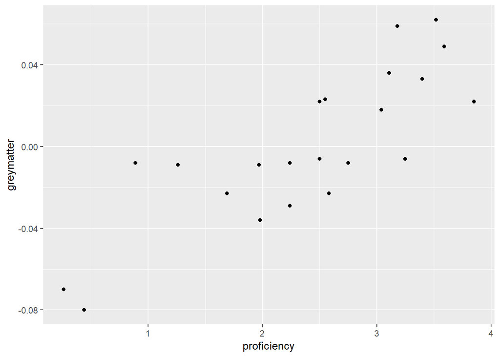

```r
ggplot(data=gmatter, mapping= aes(x= proficiency, y=greymatter))+ geom_point()
```

15b. Calculate correlation between proficiency and grey matter

```r
gmatter_mod <- lm(greymatter~proficiency, data=gmatter)
summary(gmatter_mod)%>% broom::glance()
```

```
## # A tibble: 1 x 6
##   r.squared adj.r.squared  sigma statistic    p.value    df
## *     <dbl>         <dbl>  <dbl>     <dbl>      <dbl> <int>
## 1     0.670         0.653 0.0218      40.5 0.00000326     2
```

R^2 is 0.6696, so R (our correlation coefficient) is 0.8183

15c. Test the null hypothesis of zero correlations

```r
anova(gmatter_mod)
```

```
## Analysis of Variance Table
##
## Response: greymatter
##             Df    Sum Sq   Mean Sq F value    Pr(>F)
## proficiency  1 0.0193186 0.0193186  40.539 3.264e-06 ***
## Residuals   20 0.0095308 0.0004765
## ---
## Signif. codes:  0 '***' 0.001 '**' 0.01 '*' 0.05 '.' 0.1 ' ' 1
```

We have a high F value (40.539) and a small p-value is small, (3.264e^-6), so we can reject the null hypothesis

15d. What are our assumptions in part c? We assumed a bivariate normal distribution (3D bell shaped probability instead of 2d) which features a linear relationship between X and Y, and the frequency distributions of X and Y are separately normal.

15e. Does the scatter plot support the assumptions?  
Yes it does, for our range of data, it shows a linear relationshi between the two.

### 1.2 Question 19

```r
liver <- read_csv("./data/chap16q19LiverPreparation.csv")
```

19a. Calculate the correlation coefficient between t unbound fraction and concentration.

```r
cor(liver$concentration, liver$unboundFraction)
```

```
## [1] -0.8563765
```

19b. Plot the relationship between two variables

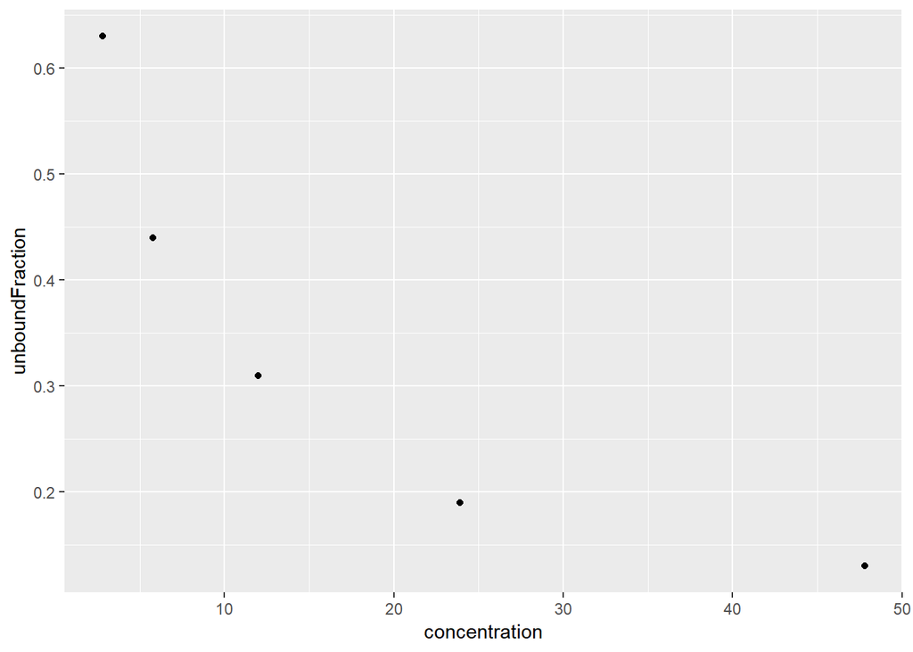

```r
ggplot(data=liver, mapping= aes(x=concentration, y=unboundFraction))+
  geom_point()
```

19c.It looks like instead of a linear relationship, it could be exponential decay.

19d. You could log transform the data to get a linear relationship.  
## 2 Correlation SE

```r
set.seed(20181011)
library(mnormt)

mat <- rmnorm(10, varcov = matrix(c(1,0.3, 0.3, 1), ncol=2)) %>%
  round(2) %>%
  as.data.frame %>%
  rename(cats = "V1", happiness_score = "V2")
```

#### 2a. Are these two variables correlated? What is the output of cor() here? what does a test show you?

```r
#model it
mat_mod <- lm(happiness_score ~ cats,data= mat)

#test
summary(mat_mod)%>% broom::glance()
```

```
## # A tibble: 1 x 6
##   r.squared adj.r.squared sigma statistic p.value    df
## *     <dbl>         <dbl> <dbl>     <dbl>   <dbl> <int>
## 1     0.457         0.389 0.534      6.73  0.0319     2
```

```r
cor(mat$cats, mat$happiness_score)
```

```
## [1] 0.6758738
```

Our correlation coefficient is 0.6759 and our F statistic is 6.728, which indicates that the regression explaines more of the variability that then residuals, indicating correlation.

#### 2b. What is the SE of the correlation based on the info from cor.test()?

```r
cor.test(mat$cats, mat$happiness_score)
```

```
##
##  Pearson's product-moment correlation
##
## data:  mat$cats and mat$happiness_score
## t = 2.5938, df = 8, p-value = 0.03193
## alternative hypothesis: true correlation is not equal to 0
## 95 percent confidence interval:
##  0.08050709 0.91578829
## sample estimates:
##       cor
## 0.6758738
```

CI= 0.08050709 -> 0.91578829 The SE of the correation is 0.2130819 (as determined from the CI in the cor.test, take the range of the CI, divide by 2*1.96)

#### 2c. What is the SE via simulation? To do this, you’ll need to use cor() and get the relevant parameter from the output (remember - you get a matrix back, so, what’s the right index!), replicate(), and sample() or dplyr::sample_n() with replace=TRUE to get, let’s say, 1000 correlations. How does this compare to your value above?

```r
se_sim <- replicate(1000, cor(sample_n(mat, nrow(mat),replace= TRUE)) [1,2])

sd(se_sim)
```

```
## [1] 0.1524226
```

They similar but the SE of cor.test() is larger. ## 3 W&S Chapter 17

### 3.1 Question 19

```r
grass <- read_csv("./data/chap17q19GrasslandNutrientsPlantSpecies.csv")
```

19a. Draw a scatter plot

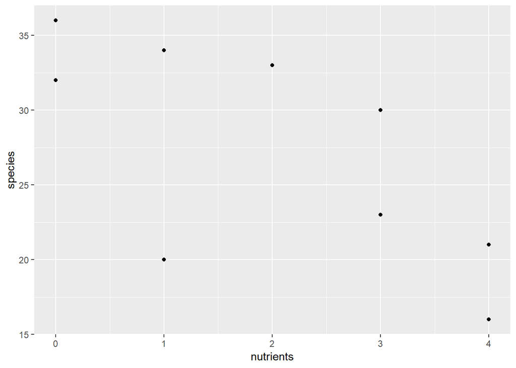

```r
ggplot(data= grass, mapping= aes(x=nutrients, y=species)) +
  geom_point()
```

X should be nutrients and y should be species.

19b. What is the rate of change in number of species per nutrient type added? Include stardard error

```r
grass_mod <- lm(grass$species~grass$nutrients)
summary(grass_mod)
```

```
##
## Call:
## lm(formula = grass$species ~ grass$nutrients)
##
## Residuals:
##     Min      1Q  Median      3Q     Max
## -10.771  -1.856   1.068   2.894   5.907
##
## Coefficients:
##                 Estimate Std. Error t value Pr(>|t|)
## (Intercept)       34.110      2.599   13.12 1.08e-06 ***
## grass$nutrients   -3.339      1.098   -3.04   0.0161 *
## ---
## Signif. codes:  0 '***' 0.001 '**' 0.01 '*' 0.05 '.' 0.1 ' ' 1
##
## Residual standard error: 5.336 on 8 degrees of freedom
## Multiple R-squared:  0.536,  Adjusted R-squared:  0.478
## F-statistic: 9.241 on 1 and 8 DF,  p-value: 0.01607
```

The rate of change is -3.339 nutrients added to species. The standard error is 1.098.

19c. Add the least squares regression to your scatter plot. What fraction of the variation in the number of plant species is “explained” by number of nutrients?

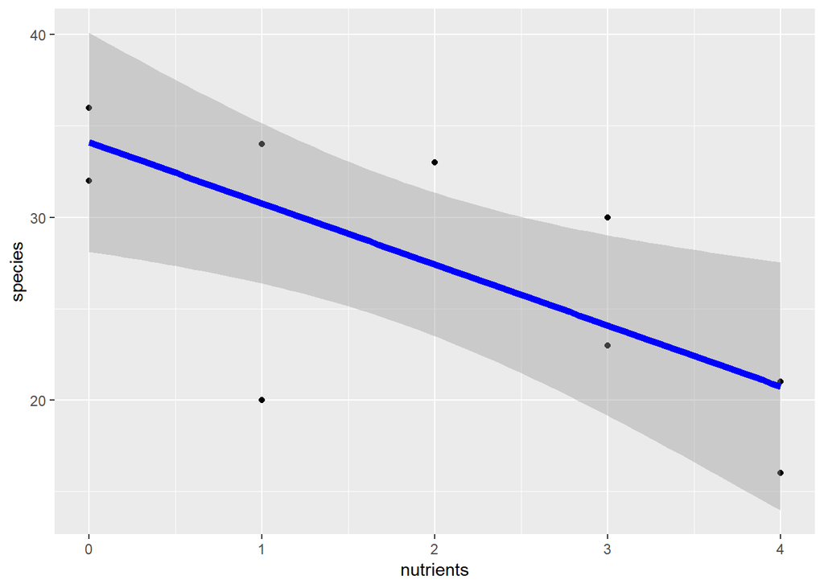

```r
ggplot(data= grass, mapping= aes(x=nutrients, y=species)) +
  geom_point() +
  stat_smooth(method= "lm",
              color= "blue",
              size=2)
```

Based on the value of r^2, 0.536 is the fraction explained by the number of nutrients since our r^2 value tells us how much our “x” explains the variance in our data.

19d. Test the null hypothesis

```r
summary(grass_mod)%>% broom::glance()
```

```
## # A tibble: 1 x 6
##   r.squared adj.r.squared sigma statistic p.value    df
## *     <dbl>         <dbl> <dbl>     <dbl>   <dbl> <int>
## 1     0.536         0.478  5.34      9.24  0.0161     2
```

P is <0.05 (p- 0.016) and F statistic is 9.24, we can reject the null that there is no correlation between the two.  
### 3.2 Question 30

```r
carbon <- read_csv("./data/chap17q30NuclearTeeth.csv")
```

### 3.3 Question 31

```r
portion <- read_csv("./data/chap17q31LastSupperPortionSize.csv")
```

31a. Calculate a regression line between year of painting and portion size. What is the trend? How rapidly (what’s the slope) has it changed in paintings?

```r
#visualization data
portion_base <-ggplot(data=portion, aes(x=year, y=portionSize))+ geom_point()
#create linear regression model
portion_mod <- lm(portionSize~year, data=portion)
print(portion_mod)
```

```
##
## Call:
## lm(formula = portionSize ~ year, data = portion)
##
## Coefficients:
## (Intercept)         year
##   -1.168842     0.003329
```

The trend is portion size increases as time goes on. The rate of change is 0.0033229 of a portion per a year. It changes slowly.

31b. What is the most plausible range of values for the slope? Calculate the 95% CI.

```r
confint(portion_mod)
```

```
##                    2.5 %      97.5 %
## (Intercept) -4.014924002 1.677239200
## year         0.001349556 0.005308266
```

Our plausible range for slope is 0.001349556 to 0.005308266

31c. Test for a change in relative portion size painted in these works with the year in which they were painted.

```r
anova(portion_mod)
```

```
## Analysis of Variance Table
##
## Response: portionSize
##           Df Sum Sq Mean Sq F value   Pr(>F)
## year       1 11.782 11.7819  11.765 0.001727 **
## Residuals 31 31.043  1.0014
## ---
## Signif. codes:  0 '***' 0.001 '**' 0.01 '*' 0.05 '.' 0.1 ' ' 1
```

31d. Draw a residual plot of the data. Can you see any cause for concern about using a linear regression?

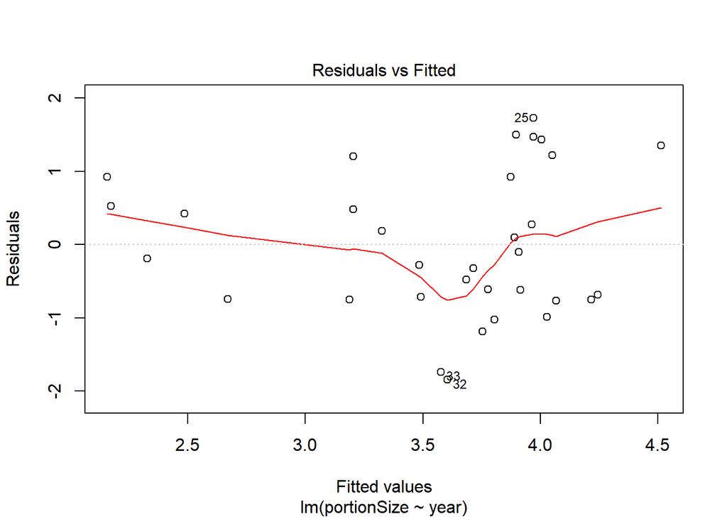

```r
plot(portion_mod, which=1)
```

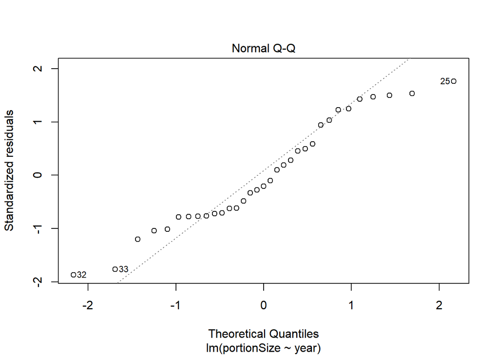

```r
plot(portion_mod, which=2)
```

The residual plot shows we don’t have a nice spread around the horizon line. Our data might violate some of the assumptions we made in our model. To address this problem, we could transform the data (ie log transformation) or use other tests like a spearmens correlation coefficient.

### 4 Intervals and simulation

Fit the deet and bites model from lab.

```r
mosq <- read_csv("./data/17q24DEETMosquiteBites.csv")
```

```r
bites_mod<- lm(mosq$bites~mosq$dose)

base_bites <- ggplot(data= mosq, mapping= aes(x= dose, y=bites))+
  geom_point() +
  stat_smooth(method= "lm",
              color= "blue",
              size=2)
```

look a vcov() applied to model

```r
vcov(bites_mod)  #returns the variance- covariance matrix for fitted model
```

```
##             (Intercept)    mosq$dose
## (Intercept)  0.09929780 -0.025986850
## mosq$dose   -0.02598685  0.007437073
```

This maintains the best fit possible, despite deviations in the slope and intercept.

```r
library(mnormt)

rmnorm(4, mean = coef(bites_mod), varcov = vcov(bites_mod))
```

```
##      (Intercept)  mosq$dose
## [1,]    4.406152 -0.5463624
## [2,]    4.078978 -0.4593143
## [3,]    3.684373 -0.3630169
## [4,]    3.619590 -0.3069827
```

#### 4a. Using geom_abline() make a plot that has the following layers and shows that these simulated lines match up well with the fit CI. 1) the data, 2) the lm fit with a CI, and 3) simulated lines. You might have to much around to make it look as good as possible.

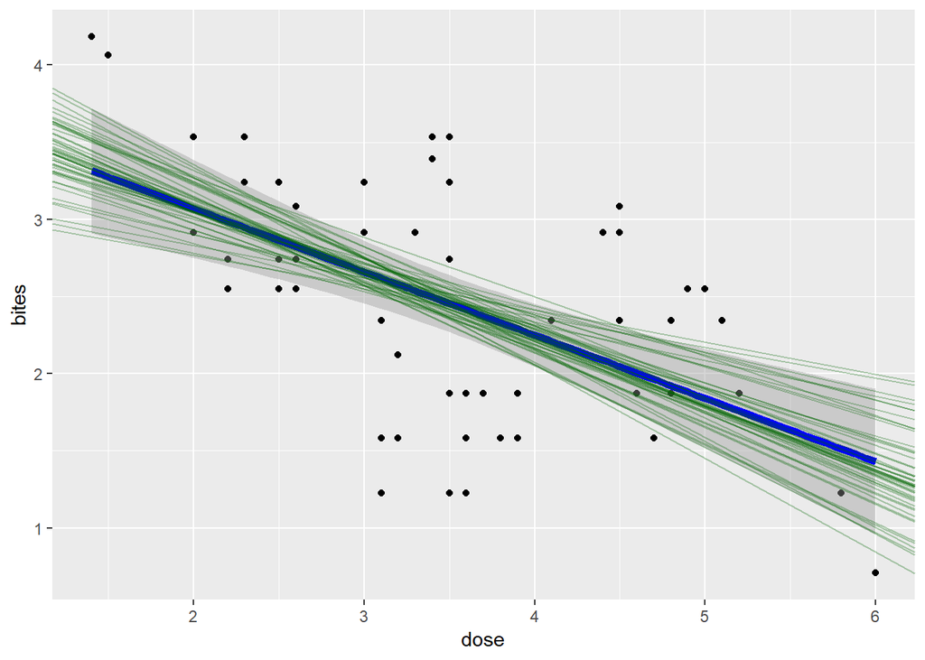

```r
#simulate lines with rmnorm
sim_coeff <- data.frame(rmnorm(50, mean = coef(bites_mod), varcov = vcov(bites_mod)))

base_bites + geom_abline(slope= sim_coeff$mosq.dose,intercept=sim_coeff$X.Intercept., color="darkgreen", alpha=0.3)
```

#### 4b. what about the prediction intervals? To each line, we can add some error drawn from the residual standard deviation. That residual can either be extracted from `summary()` or you can get the `sd` of `residuals`.Now, visualize the simulated prediction interval around the fit versus the calculated prediction interval around the fit via `predict`. **+1 extra credit for a clever visualization of all elements on one figure - however you would like**

```r
#extract residuals and add to data frame
pred_frame <- predict.lm(bites_mod, interval= "prediction")
pred_frame <- cbind(mosq, pred_frame)

#add sd for sim_coeff
sim_coeff <- sim_coeff %>%
  mutate(err= rnorm(n(), 0, sd(bites_mod$residuals)))%>%
  ungroup()
```

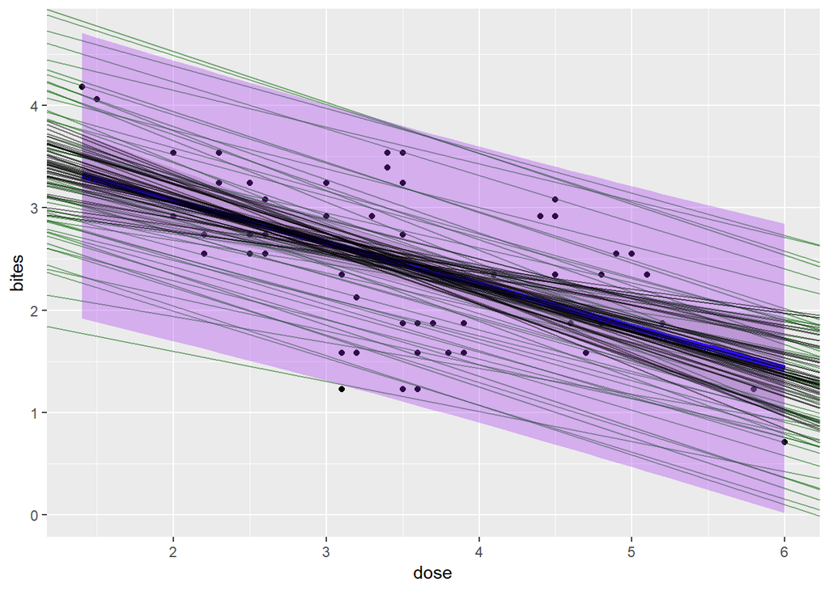

```r
#viz simulated prediction interval around fit vs calculated prediction interval around fit from "predict"

base_bites + #data with CI fit and line reg line
  geom_abline(data= sim_coeff, aes(slope=mosq.dose,intercept= err + (X.Intercept.)),
                                   color="darkgreen", alpha=0.5) + #sim prediction interval
  geom_ribbon(data=pred_frame, aes(ymin=lwr, ymax= upr), fill= "purple", alpha= 0.3)+ #calc pred. interval
   geom_abline(data = sim_coeff, aes(slope = mosq.dose, intercept = X.Intercept.), alpha = 0.5) #sim fit
```